# 第1回 関数と 1 変数の微分

経済学基礎数学II

第1回

関数と 1 変数の微分

導関数と微分の基本公式

経済学基礎数学II

第1回 — Topic01

関数とグラフ

関数の記法と一次関数の傾き

## 第1回の道のり

1

関数とグラフ

2

傾き

3

積と入れ子

4

✎

授業内演習

いまココ — 春に使った関数とグラフを、秋の道具として組み直す

## このトピックで学ぶこと

- **関数**：数を $1$ つ入れると、数が $1$ つ出てくる箱
- **記法 $f(x)$**：箱の名前が $f$、入れた数が $x$、出てきた数が $f(x)$
- **グラフ**：入れた数を横、出てきた数を縦に置いた地図
- **傾き**：横に $1$ 歩進むと、縦にどれだけ上がるか

行き先は $1$ つ。山のてっぺんでは、傾きが $0$ になる

## 関数 — 入れると数が出てくる箱

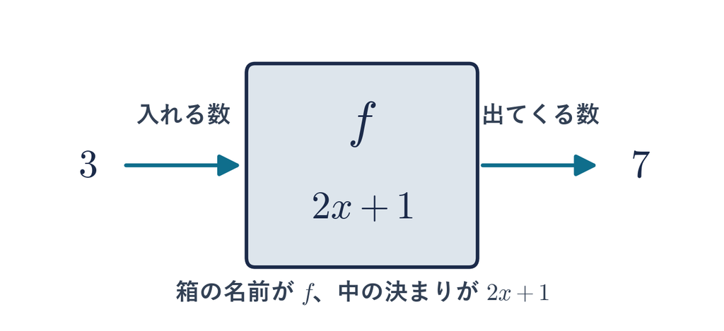

$3$ を入れると $7$ が出る。**入れる数が決まれば、出る数も $1$ つに決まる**

## $f(x)$ の読み方

用語

$$f(x) = 2x + 1, \qquad f(3) = 2 \times 3 + 1 = 7$$

- **$f$**：箱の名前。$f$ と $x$ のかけ算ではない
- **$x$**：箱に入れる数。出てくる数が $f(x)$
- **$f(3)$**：$x$ の場所に $3$ を書いただけ
- **別の箱**：名前を変えて $g$、$h$ とも書く。役目は同じ

$f(3) = 7$ は「$3$ を入れたら $7$ が出た」と読む

## グラフ — 入れた数と出た数の地図

[figure not shown]

横軸で $3$ を探して真上へ。ぶつかった点の高さが $f(3) = 7$

## 一次関数 — まっすぐな坂

公式

$$f(x) = a\,x + b$$

- **$a$**：傾き。坂の急さと向きを決める数
- **$b$**：$x = 0$ のときの高さ。坂の出発点
- **決まること**：$a$ と $b$ が決まれば、まっすぐな線が $1$ 本引ける

$f(x) = 2x + 1$ なら、傾きが $2$ で、出発点の高さが $1$

## 傾き — 横に $1$ 歩、縦にどれだけ

[figure not shown]

どこで測っても、横 $1$ に対して縦 $2$。まっすぐな坂の傾きは $1$ つの数

## ✋ たしかめ 1-1 — 傾きと、出てくる数

たしかめ 1-1

$g(x) = 3x - 2$ について、次の $2$ つを答える

1. 横に $1$ 進むと、縦にいくつ上がるか
2. $g(2)$ はいくつか
3. 答えを紙に書いたら、次のスライドで答え合わせ

⏸ PAUSE 動画を止めて $1$ 分。書けたら再生に戻る

## たしかめ 1-1 の答え — $x$ の前の数を読む

$g(x) = 3x - 2$ の傾きと、$g(2)$ の値

① どこを見る

$x$ の前についた  
数が傾き

② 使う道具

一次関数の形  
$g(x) = a\,x + b$

③ 当てはめる

$a = 3$  
$g(2) = 3 \times 2 - 2$

こたえ

傾きは $3$、$g(2) = 4$

$-2$ は出発点の高さ。傾きには入らない

## 二次関数 — $2$ 乗が入ると、線が曲がる

公式

$$h(x) = a\,x^2 + b\,x + c$$

- **$x^2$ の項**：$a$ が $0$ でなければこの項が効き、線はまっすぐでなくなる
- **$a$ の符号**：負なら山の形、正なら谷の形。一次関数の傾き $a$ とは別の役
- **春に見た名前**：この曲がった線を放物線と呼んだ

次の $2$ 枚の坂は $h(x) = -x^2 + 4x$。$a$ が $-1$ なので山の形

## 曲がった坂 — 板を当てて向きを見る

[figure not shown]

上りでは板が右上がり、下りでは右下がり。**場所が変われば向きも変わる**

## 山のてっぺん — 板が水平になる

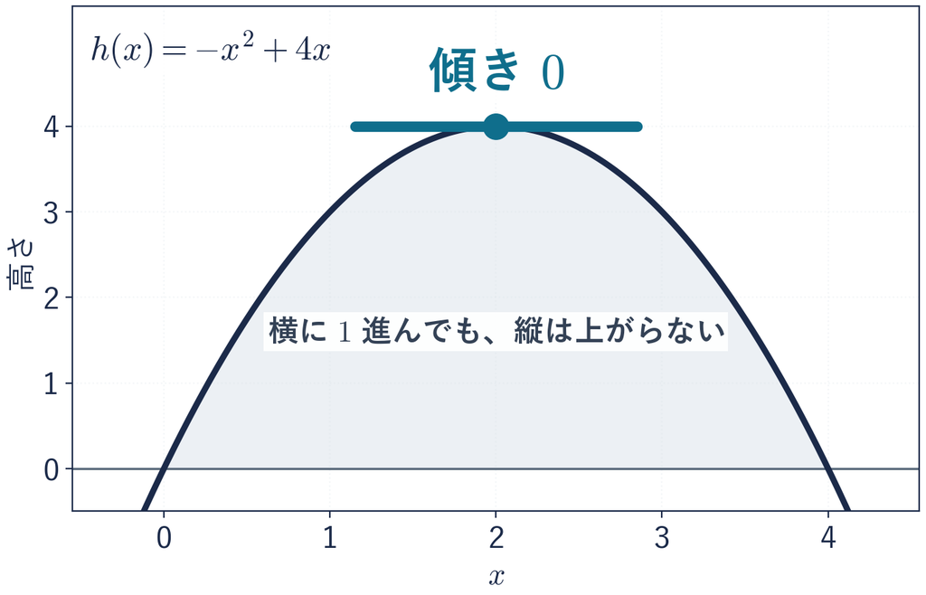

てっぺんの $1$ 点だけ板が水平。**そこでは傾きが $0$**

## まとめ — このトピックで学んだこと

- 関数は「数を入れると数が出てくる箱」。箱の名前が $f$
- $f(3)$ は $3$ を入れたときに出る数。グラフでは横軸 $3$ の真上の高さ
- 一次関数 $f(x) = a\,x + b$ の $a$ が傾き、$b$ が出発点の高さ
- 傾きは「横に $1$ 進むと、縦にどれだけ上がるか」。  
  まっすぐな坂なら $1$ つの数
- 曲がった坂では場所ごとに変わり、**山のてっぺんでは $0$**

次は **傾きが $0$ の場所**をシミュレータで探す。そこから、傾きを式で出す

経済学基礎数学II

第1回 — Topic02

導関数と $n$ 乗の公式

微分係数の定義と線形性

## 第1回の道のり

1

関数とグラフ

2

傾き

3

積と入れ子

4

✎

授業内演習

いまココ — 傾きを測り直し、微分の道具を $2$ つ手に入れる

## 前トピックの振り返り

前回のポイント — トピック1「関数とグラフ」

Q: まっすぐな坂の傾きは、どう読んだか

- **傾き**: 横に $1$ 進むと、縦にどれだけ上がるか
- **一次関数**: $f(x) = a\,x + b$ の $a$ がその数
- **曲がった坂**: 場所ごとに変わり、てっぺんでは $0$

今回はその傾きを、**式で出せる**ようにする

## なぜ傾きを式で出すのか

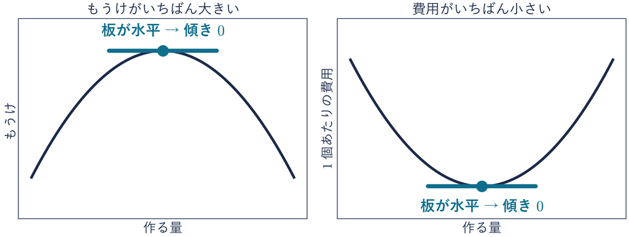

経済で知りたいのは、  
**もうけが最大の点**と**費用が最小の点**。どちらも傾きが $0$ の場所

## このトピックで学ぶこと

- **傾き**：直角三角形で「横に $1$ 進むと縦にどれだけ」を読む
- **導関数 $f'(x)$**：$f$ にダッシュを付けた記号。場所ごとに変わる傾き
- **$n$ 乗の公式**：「肩を下ろす」の一手で $x^n$ を微分する
- **線形性**：「ばらして足す」が使えれば、多項式は全部いける

秋学期に持っていく道具は $4$ つ。今回はその $2$ つ

## 今日の公式 — 先にこの $2$ つ

公式

$$(x^n)' = n\,x^{\,n-1}$$

法則（線形性）

$$\{f + g\}' = f' + g' \qquad \{c\,f\}' = c\,f'$$

右肩の $'$ は「微分する」の印。以下はこの $2$ 行の説明

## 坂のきつさは、高さでは決まらない

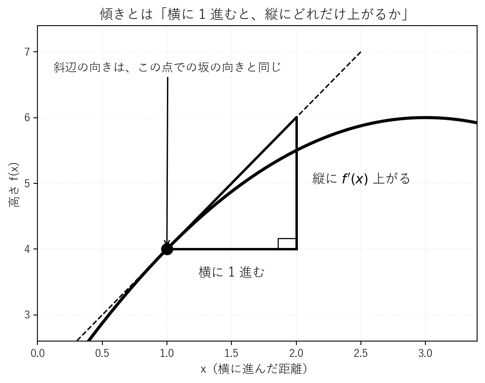

決めているのは「**横に $1$ 進むあいだに、縦にどれだけ上がるか**」＝ 傾き

## 傾きは、場所によって変わる

[figure not shown]

傾きは $1$ つの数ではなく、場所 $x$ ごとに決まる数 → **導関数 $f'(x)$**

## デモ：傾きシミュレータ

数の話

傾き $f'(x)$ は「横に $1$ 進むと、縦にいくつ上がるか」

- **何を見るか**：点を左右に動かし、その場所の接線と傾きを読む
- **図の意味**：紺＝もとの関数、青緑＝接線、橙の三角形＝横 $1$・縦 $f'(x)$
- **操作**：右の柱にタブ $4$ つ・点の位置のスライダ。点のドラッグも可

ミッション 傾きが $0$ になる場所は何か所ある  
か、タブごとに数える

※ 次のスライドへ進むときは、デモの枠の外を一度クリックしてから ← → キーを押す

[interactive chart not shown]

## 答え合わせ — 傾きが $0$ になる場所はどこか

| タブ | 傾き | 傾きが $0$ になる場所 | わかること |
| --- | --- | --- | --- |
| $x^2$ | $2x$ | $1$ か所 | そこが谷 |
| $x^3 - 3x$ | $3x^2 - 3$ | $2$ か所 | 山と谷 |
| $x^3$ | $3x^2$ | $1$ か所 | 平らなだけ。頂点ではない |
| $\sqrt{x}$ | $\tfrac{1}{2\sqrt{x}}$ | 無し | $0$ に届かない |

- **頂点**＝山のてっぺんと谷の底。傾きが $0$
- $x^3 - 3x$：山は $x = -1$、谷は $x = 1$
- 平らになるだけで、そのまま上がり続けることもある

$x^n$ まである式なら傾きは $x^{n-1}$ まで。**山と谷は多くても $n-1$ 個**

## 接線を引いて、$4$ つを見比べる

[figure not shown]

水平な接線のところが山か谷。ただし $x^3$ は平らなだけ

## $x = 2$ のまわりで、数を追いかける

$f(x) = x^3$ の $x = 2$ での傾き。**上がった高さ ÷ 進んだ幅**を、幅を縮めながら計算

| 横に進む幅 | 上がった高さ | 高さ ÷ 幅 |
| --- | --- | --- |
| $0.1$ | $1.261$ | $12.61$ |
| $0.01$ | $0.120601$ | $12.0601$ |
| $0.001$ | $0.012006001$ | $12.006001$ |

幅を小さくすると **$12$ に近づく**。これが $x = 2$ での傾き

## $n$ 乗の公式 — 肩を下ろして、$1$ 減らす

公式

$$(x^n)' = n\,x^{\,n-1}$$

- **肩の $n$**：前に下ろして、かけ算の相手にする
- **新しい肩**：もとの肩から $1$ 減らす
- **$n$ の中身**：整数でなくてよい。分数でも負でも同じ形

$f(x) = x^3$ なら $f'(2) = 3 \times 2^2 = 12$。さっきの表が近づいた $12$ と合う

## 公式の絵 — 肩の数が前に下りる

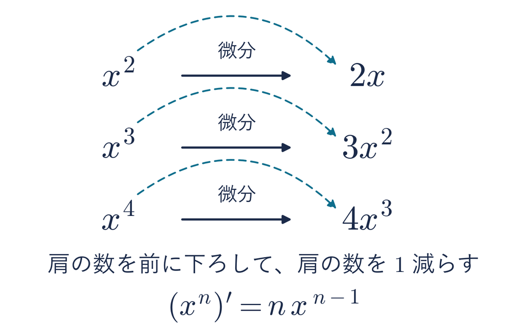

肩の数が **前へ下りて**、肩は $1$ 減る。$3$ 段とも同じ動き

## 肩の書き換え — 分数と根号

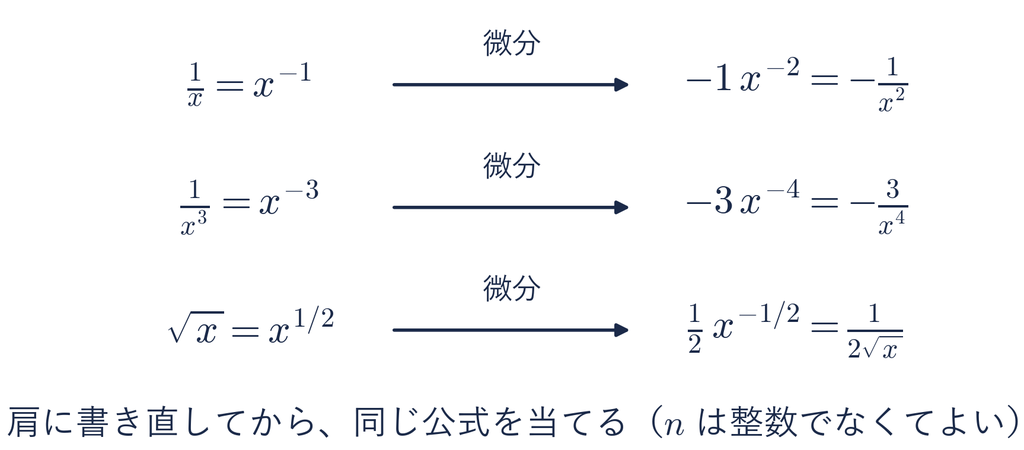

分母が $0$ の場所・根号の中が負になる場所は、はじめから外して読む

## 線形性 — ばらして足す、前の数は外へ

法則

$$\{f + g\}' = f' + g' \qquad \{c\,f\}' = c\,f'$$

- **足し算**：ばらして、それぞれ微分してから足す
- **前についた数 $c$**：$x$ で動かない数。外に出して、残りだけ微分する
- **使える形**：多項式はこの $2$ 行と $n$ 乗の公式だけで片づく

$3x^2 + 5x$ なら、$3 \cdot (x^2)'$ と $5 \cdot (x)'$ に分けてから足す

## 線形性の絵 — ばらす、外に出す

[figure not shown]

上から下へ、$2$ 段階。**ばらす** → **前の数を外へ**

## ✋ 演習 2-1・2-2 — 自分で微分する

演習 2-1・2-2

次の $2$ 問を微分する（計算ドリル1 のブロック $1$・$2$ から）

1. $f(x) = x^4$
2. $f(x) = 3x^2 + 5x$
3. 答えを紙に書いたら、次のスライドで答え合わせ

⏸ PAUSE 動画を止めて $2$ 分。解けたら再生に戻る

## 演習 2-1 の答え — 公式をそのまま当てる

$f(x) = x^4$ を微分する

① どこを見る

いちばん外側は $x$ の  
累乗ひとつだけ

② 使う道具

$n$ 乗の公式  
$(x^n)' = n\,x^{n-1}$

③ 当てはめる

肩の $4$ を前へ  
肩は $3$ に

こたえ

$f'(x) = 4x^3$

肩を $1$ 減らし忘れて $4x^4$ としないこと

## 演習 2-2 の答え — ばらして、外に出す

$f(x) = 3x^2 + 5x$ を微分する

① どこを見る

いちばん外側は ＋ で  
つながっている

② 使う道具

線形性でばらし、  
前の数を外へ出す

③ 当てはめる

$3 \cdot (x^2)' + 5 \cdot (x)'$  
$= 3 \cdot 2x + 5 \cdot 1$

こたえ

$f'(x) = 6x + 5$

$5x$ の微分は $5$。$x$ が消えるところを飛ばさない

## まとめ — このトピックで学んだこと

- 傾き＝横に $1$ 進むあいだに、縦にどれだけ上がるか
- 傾きは場所ごとに変わる。その数を返すのが導関数 $f'(x)$
- とくに **傾きが $0$ の場所**が、グラフを読む鍵
- **公式**：$(x^n)' = n\,x^{n-1}$。肩を下ろして、肩を $1$ 減らす
- **法則**：$\{f + g\}' = f' + g'$、$\{c\,f\}' = c\,f'$。ばらして足し、  
  前についた数は外へ出す
- 分数・根号は肩に書き換えてから、同じ公式を当てる

**計算ドリル1 のブロック $1$・$2$** を解く → 次は **かけ算と入れ子の微分**

経済学基礎数学II

第1回 — Topic03

積の微分と合成関数の微分

積の法則と連鎖律

## 第1回の道のり

1

関数とグラフ

2

傾き

3

積と入れ子

4

利潤最大

✎

授業内演習

いまココ — 道具の $3$ つめと $4$ つめ。かけ算と入れ子

## 前トピックの振り返り

前回のポイント — トピック2「傾き＝微分」

Q: 多項式を微分する $2$ つの道具は

- **$n$ 乗の公式**: 肩を下ろして、肩を $1$ 減らす
- **線形性**: 足し算はばらす、前についた数は外へ

今回は **足し算ではないつなぎ方**（かけ算・入れ子）を扱う

## このトピックで学ぶこと

- **ばらせない**：反例ひとつで、かけ算がばらせないと分かる
- **積の微分**：前だけ・後だけで $2$ 本の帯を足す
- **合成関数**：外と中の回り方をかけて、入れ子をほどく
- **展開しない**：$(2x+1)^{20}$ が、展開せずに微分できる

秋学期に持っていく道具 $4$ つが、これでそろう

## 今日の公式 — 先にこの $2$ つ

公式（積の微分）

$$\{f(x)\,g(x)\}' = f'(x)\,g(x) + f(x)\,g'(x)$$

公式（合成関数の微分）

$$\{f(g(x))\}' = f'(g(x)) \times g'(x)$$

どちらも「かけ算」で結ぶ。以下はこの $2$ 行の説明

## ここから積の微分

ねらい

式どうしが**かけ算**で並んだ形を、展開せずに微分する

- **使う形**：$(x+1)(x-4)$、$x^2(x+3)^3$ のように、式と式がかけ算で並ぶ形
- **いまは**：多項式なら先に展開しても解ける。答えは同じ
- **この先**：指数関数や対数関数が入ると展開できない。  
  そこではこれしか手が無い

展開でも解けるうちに、かけ算のまま微分する手を覚えておく

## かけ算もばらせるか

ばらしてみると

$f'(x)\,g'(x) = 1 \times 1 = 1$

足し算と同じつもりで、  
片方ずつ微分してかけた

先にかけてから微分

$f(x)g(x) = x \cdot x = x^2$

$(x^2)' = 2x$

こちらが正しい傾き

$f(x) = g(x) = x$ で試すと $1$ と $2x$。**かけ算はばらせない**

## 増えた面積は、細い帯が $2$ 本

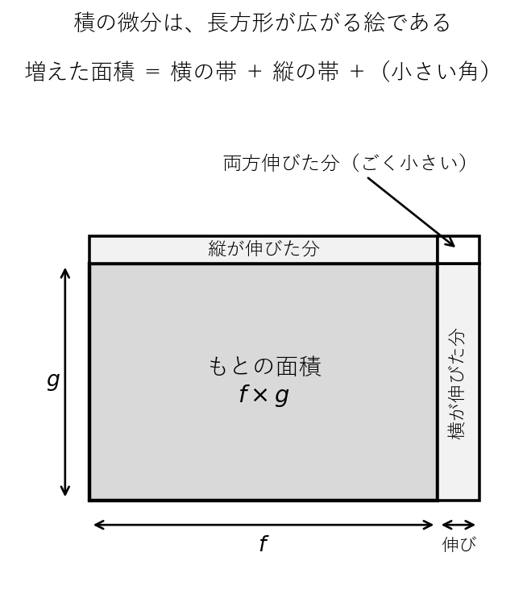

右の帯が $g \times f'$、上の帯が $f \times g'$。右上の角は小さすぎて落ちる

## 積の微分 — 前だけ微分 ＋ 後だけ微分

[figure not shown]

前を $f$、後を $g$ と名づけると $f'g + f g'$。微分するのは片方ずつ

## 合成関数 — 関数の中に、関数を入れる

用語

$$g(x) = 2x + 1, \quad f(t) = t^2 \qquad f(g(x)) = (2x+1)^2$$

- **$f(g(x))$ の読み方**：中の $g$ に $x$ を入れ、出てきた数を外の $f$ に入れる
- **$t$**：外の箱に入れる数の名前。そこへ $g(x)$ がまるごと入る
- **順番**：中が先、外が後。$x$ が $3$ なら $g(3) = 7$、$f(7) = 49$

$(2x+1)^2$ は、中で $2x+1$ を作り、外で $2$ 乗した形

## 入れ子は、かみ合った歯車 $2$ つ

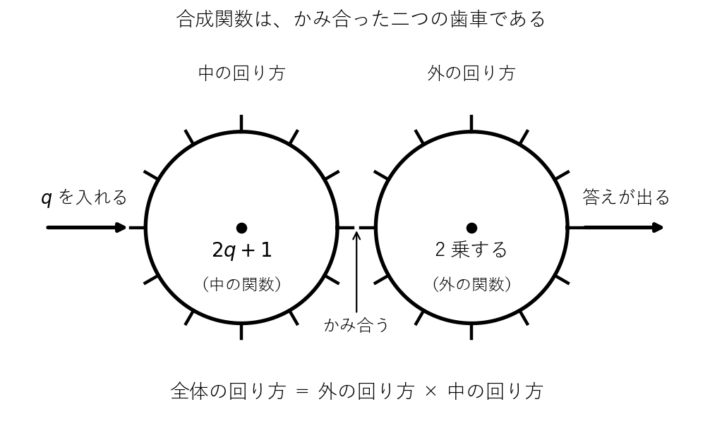

中が $2$ 倍速く回れば外も $2$ 倍。**全体の回り方は $2$ つのかけ算**

## $3$ 手でほどく — 外微分、内微分、かける

[figure not shown]

**外微分**＝外だけを微分。**内微分**＝中だけを微分。この $2$ つをかけて終わり

## 外と中を見分ける

**カッコごとの累乗**が外、**カッコの中身**が中。積の「前・後」とは別の役

| 式 | 外 | 中 | 微分すると |
| --- | --- | --- | --- |
| $(2x+1)^2$ | $2$ 乗 | $2x+1$ | $4(2x+1)$ |
| $(5x^2+x)^3$ | $3$ 乗 | $5x^2+x$ | $3(5x^2+x)^2(10x+1)$ |
| $(x^2+1)^4$ | $4$ 乗 | $x^2+1$ | $8x(x^2+1)^3$ |

答えは**くくり出した形のまま**でよい

## デモ：かけ算と入れ子をほどく

数の話

$4$ 行の式変形で $\{fg\}' = f'g + fg'$ と  
$\{f(g(x))\}' = f'(g(x)) \times g'(x)$ を使う

- **何を見るか**：式が $1$ 行ずつ出る。進めて自分の答えと見くらべる
- **図の意味**：左＝式、右＝その行でした手。青緑の縦線＝いま出た行
- **操作**：右の柱のタブと「次の行」（クリックでも進む）

ミッション 先に紙で答えを書いてから、  
$4$ 行目まで進めて見くらべる

※ 次のスライドへ進むときは、デモの枠の外を一度クリックしてから ← → キーを押す

[interactive chart not shown]

## よくある失敗 — この $2$ つで落とす

✕ $f'g'$ としてしまう

$\{(x+1)(x-4)\}'$ を $1 \times 1 = 1$

足し算はばらせたので、  
かけ算もばらせそうに見える

○ 正しくは  
$1 \cdot (x-4) + (x+1) \cdot 1 = 2x - 3$

✕ 内微分を忘れる

$\{(2x+1)^5\}'$ を  
$5(2x+1)^4$ で止める

外を微分したところで手が止まる

○ 正しくは  
$5(2x+1)^4 \times 2 = 10(2x+1)^4$

見直す $2$ か所：積の微分は**項が $2$ 本**あるか、合成関数は**内微分をかけた**か

## ✋ 演習 3-1・3-2 — 自分で微分する

演習 3-1・3-2

次の $2$ 問を微分する（計算ドリル1 のブロック $3$・$4$ から）

1. $f(x) = (x+1)(x-4)$
2. $f(x) = (x+5)^3$
3. 答えを紙に書いたら、次のスライドで答え合わせ

⏸ PAUSE 動画を止めて $2$ 分。解けたら再生に戻る

## 演習 3-1 の答え — 片方ずつ微分する

$f(x) = (x+1)(x-4)$ を微分する

① どこを見る

いちばん外側は  
式どうしのかけ算

② 使う道具

積の微分  
$f'g + f g'$

③ 当てはめる

$1 \cdot (x-4)$  
$+ (x+1) \cdot 1$

こたえ

$f'(x) = 2x - 3$

展開して $x^2 - 3x - 4$ から微分しても、同じ答えになる

## 演習 3-2 の答え — 外を微分して、中身を入れる

$f(x) = (x+5)^3$ を微分する

① どこを見る

いちばん外側は  
カッコごとの累乗

② 使う道具

合成関数の微分  
外 → 中 → かける

③ 当てはめる

$3(x+5)^2 \times 1$

こたえ

$f'(x) = 3(x+5)^2$

中の微分は $1$。かけても形が変わらないので、飛ばしたくなるところ

## まとめ — このトピックで学んだこと

- かけ算はばらせない。$f = g = x$ で $1$ と $2x$ に割れる
- 積の微分 $\{fg\}' = f'g + f g'$ — 微分するのは片方ずつ
- 入れ子は歯車 $2$ つ。$\{f(g(x))\}' = f'(g(x)) \times g'(x)$
- 外を微分したら、$x$ ではなく**中身**を入れる
- 答えはくくり出した形のままでよい。展開しない

経済学基礎数学II

第1回 — Topic04

限界費用と利潤最大

経済学への応用

## 第1回の道のり

1

関数とグラフ

2

傾き

3

積と入れ子

4

利潤最大

✎

授業内演習

いまココ — 限界費用は微分。利潤最大も微分で解く

## 前トピックの振り返り

前回のポイント — トピック3「積の微分・合成関数の微分」

Q: かけ算と入れ子、それぞれの公式は

- **積の微分**: $f'g + f g'$（微分するのは片方ずつ）
- **合成関数**: $f'(g(x)) \times g'(x)$（外 → 中 → かける）

道具は $4$ つそろった。今回は **経済の費用** に使う

## このトピックで学ぶこと

- **費用**：固定費と変動費。作るほど次の $1$ 個が高くつく
- **限界費用**：費用 $C(q)$ の微分 $C'(q)$ のこと
- **利潤最大**：値段 ＝ 限界費用 を微分で解く
- **単位**：「$1$ 個あたり万円」が抜けると意味が変わる

限界費用は微分そのもの。だから利潤最大も微分で解ける

## 固定費と変動費

用語

**費用** ＝ 固定費 ＋ 変動費

- **費用**：品物を $q$ 個作るのにかかるお金の合計
- **固定費**：作らなくてもかかる。パン屋の家賃・オーブン
- **変動費**：作るほど増える。パン屋の小麦粉・電気代

教科書の工場は $q^2 + 6q + 40$（万円）。$40$ が固定費、残りが変動費

## 次の $1$ 個の費用の増え方

[figure not shown]

あとの $1$ 個ほど費用が大きく増える。だから曲線は上へ曲がる

## 工場ごとの費用の曲がり方

[figure not shown]

$11$ 個目の費用は $6$・$27$・$48$ 万円。曲がり方は工場の作り方で決まる

## 利潤が最大になる個数

[figure not shown]

てっぺんを探す鍵は次の $1$ 個の費用。それを式から一発で出すのが微分

## 限界費用の定義

用語

**限界費用** ＝ 費用 $C(q)$ を微分した $C'(q)$

- **$q$**：作る個数（個）
- **$C(q)$**：費用の合計（万円）。かけ算ではない
- **例**：$C(q) = q^2 + 6q + 40$ なら $C'(q) = 2q + 6$
- **限界**：経済では傾きのこと。限界効用・限界生産力も同じ形

$C(10) = 200$ は $10$ 個ぜんぶ、$C'(10) = 26$ はほぼ $11$ 個目の費用（実際は $27$）

## 限界費用 — 費用の曲線の傾き

[figure not shown]

$C'(10) = 26$ は接線の傾き。実際の差 $27$ に**およそ**等しい

## 単位を落とすと、意味が変わる

単位を落とすと

「$C'(10) = 26$ 万円」  
$10$ 個作るのに $26$ 万円、と読める  
実際の費用は $C(10) = 200$ 万円

単位まで書くと

「$C'(10) = 26$  
（$1$ 個あたり万円）」  
$11$ 個目におよそ $26$ 万  
円、と読める

$C$ は万円、$C'$ は **$1$ 個あたり万円**。答えは単位まで込みで書く

## デモ：限界費用シミュレータ

数の話

$C(q) = q^2 + 6q + 40$ なら $C'(q) = 2q + 6$

- **何を見るか**：接線の傾きと、実際の増え方をくらべる
- **図の意味**：橙＝費用、青緑＝接線、灰＝$1$ 個ぶんの段差
- **操作**：右の柱にタブ $3$ つ（工場）と $q$ のスライダ

ミッション 先に紙で $C'(10)$ を出してから確かめる

※ 次のスライドへ進むときは、デモの枠の外を一度クリックしてから ← → キーを押す

[interactive chart not shown]

## ◼ 利潤最大の求め方

利潤最大の条件

値段 $p$ ＝ 限界費用 $C'(q)$ のところで、利潤が最大

- **STEP 1** 利潤を式にする：$\pi(q) = 26q - C(q)$
- **STEP 2** 微分して $0$ とおく：$\pi'(q) = 26 - C'(q) = 0$
- **STEP 3** $2q + 6 = 26$ を解く：$q = 10$、$\pi(10) = 60$ 万円

$\pi$（パイ）は利潤。円周率ではない。答えは山のてっぺんと同じ

## ✋ 演習 4-1・4-2 微分と限界費用

演習 4-1・4-2

次の $2$ 問（計算ドリル1 のブロック $5$・$6$ から）

1. $f(x) = 5x^3 - \dfrac{2}{x}$ を微分する
2. 費用 $C(q) = q^2 + 8q + 50$ の限界費用と、$q = 5$ での値
3. 答えを紙に書いたら、次のスライドで答え合わせ

⏸ PAUSE 動画を止めて $3$ 分。解けたら再生に戻る

## 演習 4-1 の答え — 肩に書き直してから

$f(x) = 5x^3 - \frac{2}{x}$ を微分する

① どこを見る

$2$ つの項の引き算  
1 項ずつ微分できる

② 使う道具

線形性でばらす  
$2/x = 2x^{-1}$

③ 当てはめる

$5 \cdot 3x^2 - 2 \cdot (-x^{-2})$

こたえ

$f'(x) = 15x^2 + \frac{2}{x^2}$

うしろの符号に注意。マイナスが $2$ つ重なって ＋ に変わる

## 演習 4-2 の答え — 単位まで書いて終わり

$C(q) = q^2 + 8q + 50$ の限界費用と $C'(5)$

① どこを見る

限界費用は  
$C(q)$ の微分

② 使う道具

線形性と  
$n$ 乗の公式

③ 当てはめる

$C'(q) = 2q + 8$  
に $q = 5$ を入れる

こたえ

$C'(5) = 18$（$1$ 個あたり万円）

「$18$ 万円」だけで止めると、$5$ 個で $18$ 万円と読めてしまう

## まとめ — このトピックで学んだこと

- 費用は固定費と変動費。作るほど**次の $1$ 個**が高くつく
- 限界費用は費用の微分 $C'(q)$。経済の「限界○○」はすべて微分
- 利潤最大は $\pi'(q) = 0$、つまり 値段 ＝ 限界費用
- 傾き $C'(q)$ と実際の増え方は別物。**曲がっていれば**「およそ」で結ぶ
- 導関数には単位が付く。**$1$ 個あたり万円**まで書いて答え

**計算ドリル1 のブロック $5$・$6$** を解く → 第1回はここまで